# Email Classification Using Natural Language Processing

## Exploratory Data Analysis (EDA) - Part one: unigram

The “bag-of-words” model will try to use the word frequency to determine a category of text, while the n-gram will try to determine the category by analyzing a group of n words in a text.

Here is how the book describes:

> *the word “quarter” might be very frequent in both the business and sports category, but the four-word sequence “first quarter earnings report” is only common in business while “fourth quarter touchdown passes” in sports.* (Chapter 23 - Natural Language Processing)

Our objective during the EDA is to find out is to determine what model might be a better fit for text categorization.

OBS:After both steps above, a .csv file was created, but the file is too large (755MB) via R markdown. Please, [click here to download](https://www.dropbox.com/s/r0ckgo9v21b5wp5/yelp_dataset%20dataset.csv?dl=0) the file and run this analysis.

```r
# Initialize dataset (paste the path to the file in your computer)
data <- read.csv("/Users/andrew.ferreira/Dropbox (Life.Church)/Mac/Downloads/yelp_dataset/yelp_dataset_dataset.csv")
# uncomment if you want to run a sample data <- sample_n(data, 15000)

#Select only the necessary columns
dataset <- data %>%
  select(text, category)

dataset$category <- as.factor(dataset$category)

head(dataset,10)
```

```
##                                                                                                                                                                                                                                                                                                          …
## 1                                                                                                                                                                                                                                                                                                        …
## 2                                                                                                                                                                                                                                                                                                        …
## 3                                                                                                                                                                                                                                                                                                        …
## 4                                                                                                                 If I were reviewing the non-MD staff here, this would easily be five stars! From check-in at the ER front desk to triage intake (with Kent) to the x-ray tech, they were fantastic. Hum…
## 5                                                                                                                                                                                                                                                                                                        …
## 6                                                                                                                                                                                                                                                                                                        …
## 7                                                                                                                                   I am not much of a fan of recruiters in general but the guy I dealt with at BHS makes me feel that he did a terrible job representing the company.  For a recruiter h…
## 8                                                                                                                                                                                                                                                                                                        …
## 9  Overall, Thai Noon is outstanding!  We came here for a quick dinner before a show at Alberta Rose Theater, and came away very impressed!  The food is among the best quality Thai I've had, and the kitchen gets the food out incredibly quickly.\n\nThe chicken won ton appetizer was staggeringly go…
## 10                                                                                                                                                                                                                                                                                                       …
##    category
## 1     funny
## 2    useful
## 3      cool
## 4    useful
## 5    useful
## 6    useful
## 7    useful
## 8    useful
## 9    useful
## 10   useful
```

The process of dividing a text into a sequence of words (either 1 or n) is called tokenization. The code below will split the texts into words, and count the frequency of each of them.

```r
# Separate and count the frequency each word
datasetWords <- dataset %>%
  unnest_tokens(word, text) %>%
  count(category, word, sort = TRUE)


# Count the number of words in each category
datasetTotalWords <- datasetWords %>%
  group_by(category) %>%
  summarize(total = sum(n))

# Show the number of times each word appears in each category in contrast
# with the amount of words in that category
categoryWords <- left_join(datasetWords, datasetTotalWords)
head(categoryWords, 20)
```

```
##    category word       n    total
## 1    useful  the 4506474 93029434
## 2    useful  and 3155018 93029434
## 3    useful    i 2567316 93029434
## 4    useful   to 2405249 93029434
## 5    useful    a 2385019 93029434
## 6    useful  was 1518851 93029434
## 7      cool  the 1453224 28891154
## 8    useful   of 1374422 93029434
## 9    useful   it 1117261 93029434
## 10   useful  for 1104156 93029434
## 11   useful   in 1079145 93029434
## 12   useful   is 1052007 93029434
## 13     cool  and 1022403 28891154
## 14   useful   my  926625 93029434
## 15   useful that  874538 93029434
## 16    funny  the  849733 17688656
## 17     cool    a  786634 28891154
## 18   useful they  770813 93029434
## 19   useful with  766747 93029434
## 20     cool    i  750248 28891154
```

At this point we can see, just by looking at the top 20, that vague words like “the,” “and,” “for,” are very common. Let’s take a look at the word frequency distribution in each category

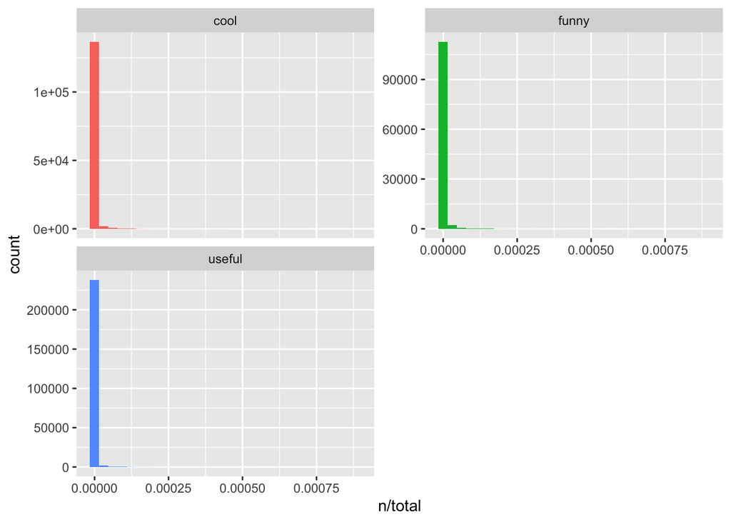

```r
ggplot(categoryWords, aes(n/total, fill = category)) +
  geom_histogram(show.legend = FALSE) +
  xlim(NA, 0.0009) +
  facet_wrap(~category, ncol = 2, scales = "free_y")
```

It seems like the frequency of those vague and common words are ridiculously high skewing our data. Another possible explanation to this chart is some very rare words at the end.

Let’s rank the appearance of each word in each category where the most frequent word is the number 1.

```r
# Rank each word based on frequency
freq_by_rank <- categoryWords %>%
  group_by(category) %>%
  mutate(rank = row_number(),
         `term frequency` = n/total) %>%
  ungroup()

# Show top 20
head(freq_by_rank, 20)
```

```
## # A tibble: 20 × 6
##    category word        n    total  rank `term frequency`
##    <fct>    <chr>   <int>    <int> <int>            <dbl>
##  1 useful   the   4506474 93029434     1          0.0484
##  2 useful   and   3155018 93029434     2          0.0339
##  3 useful   i     2567316 93029434     3          0.0276
##  4 useful   to    2405249 93029434     4          0.0259
##  5 useful   a     2385019 93029434     5          0.0256
##  6 useful   was   1518851 93029434     6          0.0163
##  7 cool     the   1453224 28891154     1          0.0503
##  8 useful   of    1374422 93029434     7          0.0148
##  9 useful   it    1117261 93029434     8          0.0120
## 10 useful   for   1104156 93029434     9          0.0119
## 11 useful   in    1079145 93029434    10          0.0116
## 12 useful   is    1052007 93029434    11          0.0113
## 13 cool     and   1022403 28891154     2          0.0354
## 14 useful   my     926625 93029434    12          0.00996
## 15 useful   that   874538 93029434    13          0.00940
## 16 funny    the    849733 17688656     1          0.0480
## 17 cool     a      786634 28891154     3          0.0272
## 18 useful   they   770813 93029434    14          0.00829
## 19 useful   with   766747 93029434    15          0.00824
## 20 cool     i      750248 28891154     4          0.0260
```

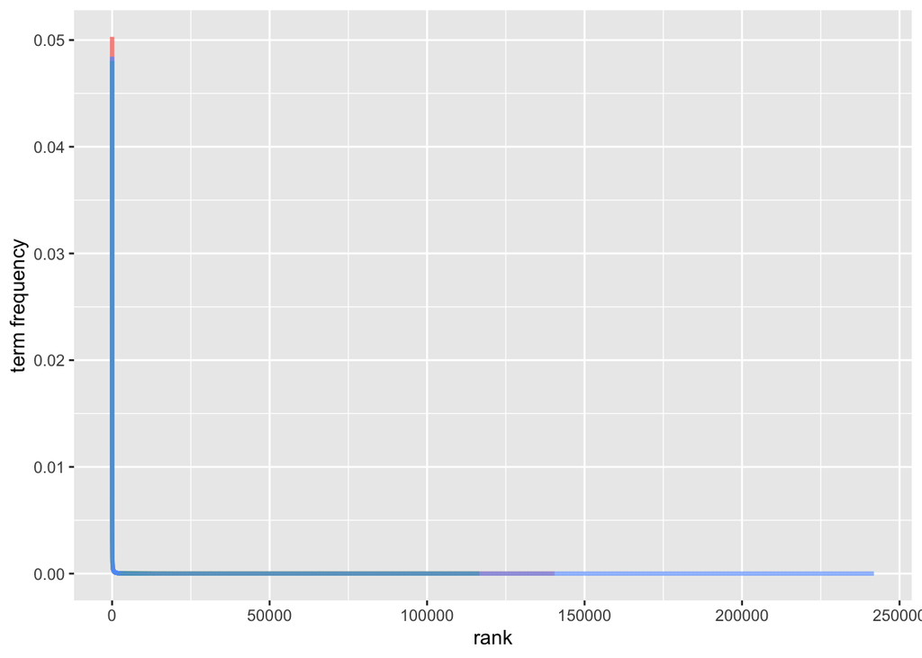

```r
# Rank x term Frequency
freq_by_rank %>%
  ggplot(aes(rank, `term frequency`, color = category)) +
  geom_line(size = 1.1, alpha = 0.8, show.legend = FALSE)
```

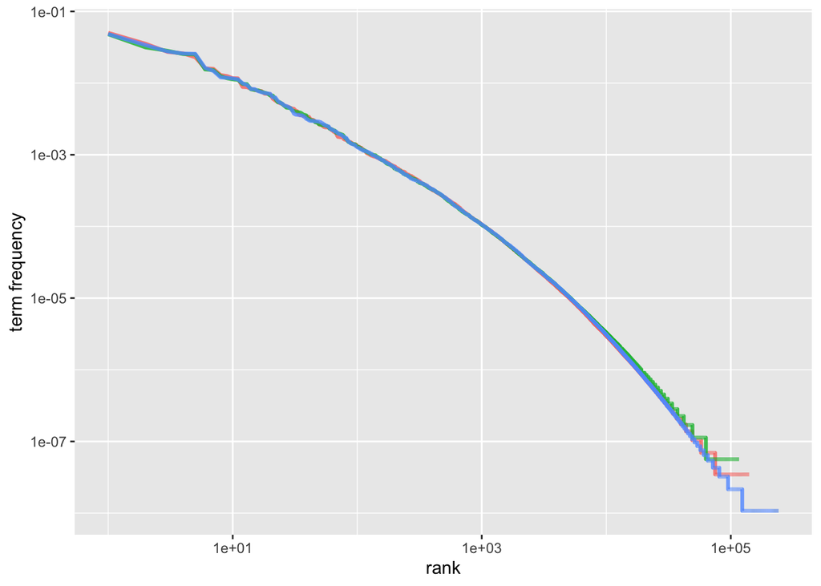

```r
# Rank x term Frequency (log-log coordinates)
freq_by_rank %>%
  ggplot(aes(rank, `term frequency`, color = category)) +
  geom_line(size = 1.1, alpha = 0.8, show.legend = FALSE) +
  scale_x_log10() +
  scale_y_log10()
```

The chart above is a very import chart, because we can clearly see that the frequency of words are very similar in the three categories (cool, funny, and useful). This is a strong indicator that the “bag-of-words” might not be a good fit for us.

However, at the end of each line we can see a distinction. Maybe the frequency of some rare words in each category might be strong enough to predict the category.

Let’s create linear model based on word frequency, just to confirm what we discovered so far.

```r
# Let's filter by rank, eliminating the top 10 words (the, of, and, etc.) and
# including up to 5000
rank_subset <- freq_by_rank %>%
  filter(rank < 5000,
         rank > 10)

lm(log10(`term frequency`) ~ log10(rank), data = rank_subset)
```

```
##
## Call:
## lm(formula = log10(`term frequency`) ~ log10(rank), data = rank_subset)
##
## Coefficients:
## (Intercept)  log10(rank)
##     -0.1981      -1.2771
```

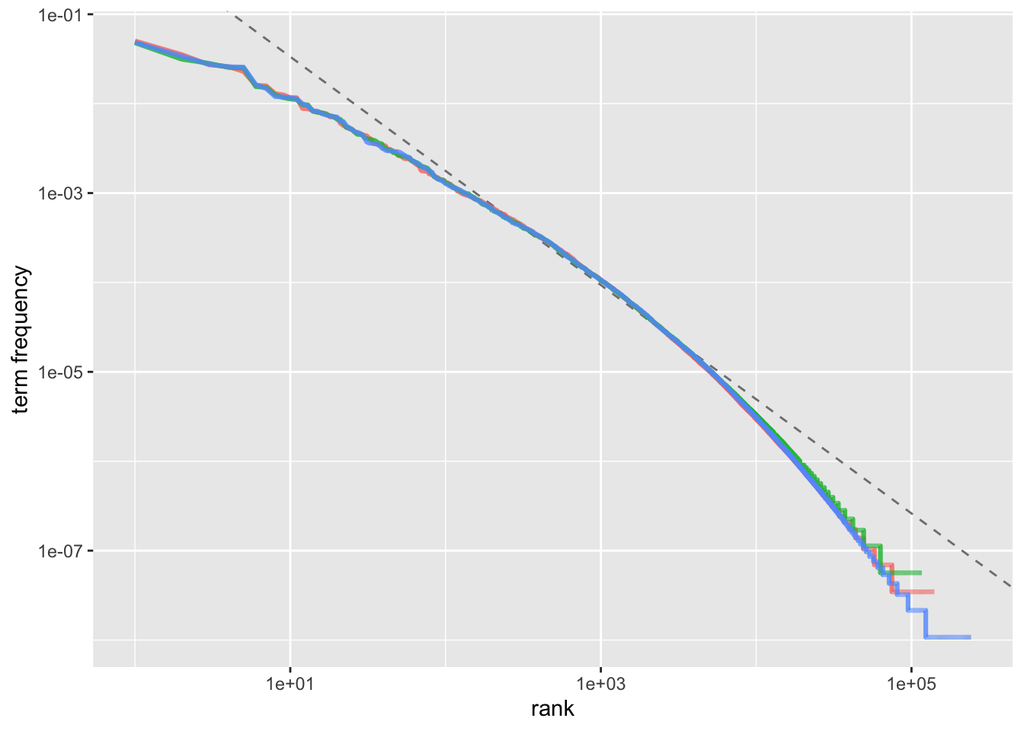

```r
# Outcome: Intercept: -0.1981 Slope: -1.2771

# I manually copy and past the intercept and slope
freq_by_rank %>%
  ggplot(aes(rank, `term frequency`, color = category)) +
  geom_abline(intercept = -0.1981, slope = -1.2771,
              color = "gray50", linetype = 2) +
  geom_line(size = 1.1, alpha = 0.8, show.legend = FALSE) +
  scale_x_log10() +
  scale_y_log10()
```

As we can see, the frequency of a word in our dataset does not seem to fit very well the linear model.

There is a function in the tidytext package that will help us to decrease the weight of super common words, and increase the weight of words that are not super frequent.

Julia Silge and David Robinson will say

> Calculating tf-idf attempts to find the words that are important (i.e., common) in a text, but not too common. (Source: Text Mining with R)

```r
# Call function for each category
category_tf_idf <- categoryWords %>%
  bind_tf_idf(word, category, n)

# Print top 20
head(category_tf_idf, 20)
```

```
##    category word       n    total          tf idf tf_idf
## 1    useful  the 4506474 93029434 0.048441378   0      0
## 2    useful  and 3155018 93029434 0.033914191   0      0
## 3    useful    i 2567316 93029434 0.027596814   0      0
## 4    useful   to 2405249 93029434 0.025854710   0      0
## 5    useful    a 2385019 93029434 0.025637252   0      0
## 6    useful  was 1518851 93029434 0.016326564   0      0
## 7      cool  the 1453224 28891154 0.050299964   0      0
## 8    useful   of 1374422 93029434 0.014774055   0      0
## 9    useful   it 1117261 93029434 0.012009758   0      0
## 10   useful  for 1104156 93029434 0.011868889   0      0
## 11   useful   in 1079145 93029434 0.011600038   0      0
## 12   useful   is 1052007 93029434 0.011308324   0      0
## 13     cool  and 1022403 28891154 0.035388098   0      0
## 14   useful   my  926625 93029434 0.009960557   0      0
## 15   useful that  874538 93029434 0.009400659   0      0
## 16    funny  the  849733 17688656 0.048038302   0      0
## 17     cool    a  786634 28891154 0.027227504   0      0
## 18   useful they  770813 93029434 0.008285689   0      0
## 19   useful with  766747 93029434 0.008241983   0      0
## 20     cool    i  750248 28891154 0.025968087   0      0
```

```r
# We can see that the tf_idf for vague and common words are very close to 0,
# and the idf for them is 0 because those words appears in the three categories
# we are looking at

# We can arrange the table to show the words that are more specific and frequent
# in each category
category_tf_idf <- category_tf_idf %>%
  select(-total) %>%
  arrange(desc(tf_idf))

# Let's look the top 20
unigram_tf_idf <- category_tf_idf %>%
  group_by(category) %>%
  slice_max(tf_idf, n = 20) %>%
  ungroup() %>%
  ggplot(aes(tf_idf, fct_reorder(word, tf_idf), fill = category)) +
  geom_col(show.legend = FALSE) +
  facet_wrap(~category, ncol = 2, scales = "free") +
  labs(x = "tf-idf", y = NULL)

head(category_tf_idf, 20)
```

```
##    category        word   n           tf       idf       tf_idf
## 1     funny     samdung  24 1.356802e-06 1.0986123 1.490599e-06
## 2     funny          哱  24 1.356802e-06 1.0986123 1.490599e-06
## 3     funny       smmag  19 1.074135e-06 1.0986123 1.180058e-06
## 4     funny       oonts  18 1.017601e-06 1.0986123 1.117949e-06
## 5    useful     flipkey 233 2.504584e-06 0.4054651 1.015521e-06
## 6     funny  172.17.1.1  14 7.914677e-07 1.0986123 8.695161e-07
## 7     funny        dexy  11 6.218675e-07 1.0986123 6.831913e-07
## 8      cool    brassica  48 1.661408e-06 0.4054651 6.736431e-07
## 9    useful   shanthala  57 6.127093e-07 1.0986123 6.731300e-07
## 10     cool        luci  45 1.557570e-06 0.4054651 6.315404e-07
## 11     cool       brien  42 1.453732e-06 0.4054651 5.894377e-07
## 12   useful  recruiters 133 1.429655e-06 0.4054651 5.796752e-07
## 13   useful     sinervo  49 5.267150e-07 1.0986123 5.786556e-07
## 14   useful        abey  48 5.159657e-07 1.0986123 5.668463e-07
## 15   useful terminating  48 5.159657e-07 1.0986123 5.668463e-07
## 16    funny      burjer   9 5.088007e-07 1.0986123 5.589747e-07
## 17    funny    sumitomo   9 5.088007e-07 1.0986123 5.589747e-07
## 18    funny          婆   9 5.088007e-07 1.0986123 5.589747e-07
## 19   useful    daycares 126 1.354410e-06 0.4054651 5.491660e-07
## 20   useful      kieran  46 4.944672e-07 1.0986123 5.432277e-07
```

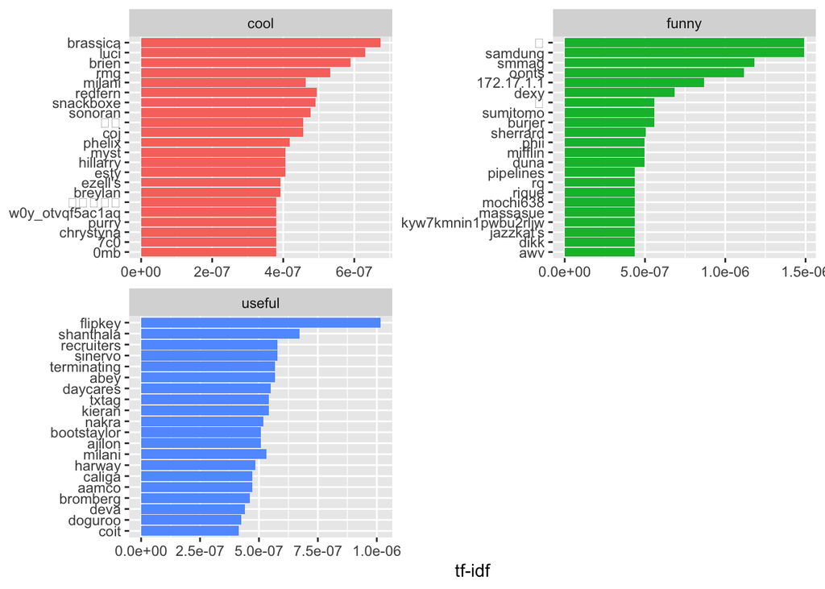

```r
unigram_tf_idf
```

The charts above is showing us the 20 most strong words of each category. While words like ‘daycares’ or ‘recruiters’ kind of make sense for useful reviews, it is hard to find a “funny” or “cool” word in the top 20. Maybe now it is a good time to start looking at a group of words, or n-gram.

# Exploratory Data Analysis (EDA) - Part two: bigram and trigram

Let’s see if capturing the interaction between two (bigram) and three (trigram) brings more meaning to those top words. It might still be vague because of the size of our dataset, but this might help us decide between the bag-of-words model and the ngram model. If the EDA do not answer our question, we might jump straight to modeling the data and analysing accuracy or we can try smoothing the n-gram.

```r
set.seed(2022)

# Getting a sample to calculate tri and bi grams
dataset_bi_sample <- sample_frac(dataset, .10)
dataset_tri_sample <- sample_frac(dataset, .10)

# preparing bigram dataset
dataset_bi_sample <-  dataset_bi_sample %>%
  unnest_tokens(bigram, text, token = "ngrams", n = 2)

dataset_bi_count <- dataset_bi_sample %>%
  count(bigram, sort = TRUE)

# preparing trigram dataset
dataset_tri_sample <-  dataset_tri_sample %>%
  unnest_tokens(trigram, text, token = "ngrams", n = 3)

dataset_tri_count <- dataset_tri_sample %>%
  count(trigram, sort = TRUE)

# print results
head(dataset_bi_sample, 10)
```

```
##    category       bigram
## 1     funny eek methinks
## 2     funny methinks not
## 3     funny       not is
## 4     funny   is correct
## 5     funny    correct i
## 6     funny     i rarely
## 7     funny   rarely eat
## 8     funny   eat bagels
## 9     funny   bagels but
## 10    funny        but i
```

```r
head(dataset_bi_count, 10)
```

```
##        bigram     n
## 1      of the 45397
## 2      it was 39824
## 3      in the 39436
## 4     and the 35776
## 5       i was 31847
## 6      on the 28954
## 7       and i 27374
## 8  this place 26258
## 9      to the 25561
## 10    for the 23875
```

```r
head(dataset_tri_count, 10)
```

```
##          trigram    n
## 1     one of the 6286
## 2  this place is 5998
## 3     and it was 5755
## 4       a lot of 5464
## 5       it was a 4865
## 6   the food was 4584
## 7    the food is 4107
## 8       i had to 3602
## 9      this is a 3507
## 10     i had the 3279
```

```r
head(dataset_tri_sample, 10)
```

```
##    category                 trigram
## 1    useful     i visited vancouver
## 2    useful   visited vancouver few
## 3    useful     vancouver few weeks
## 4    useful           few weeks ago
## 5    useful           weeks ago and
## 6    useful               ago and i
## 7    useful               and i had
## 8    useful           i had amazing
## 9    useful  had amazing experience
## 10   useful amazing experience with
```

The trigram is too large to compute and bigram was taking too long, so I had to create a sample dataset of only 10% of the original dataset and 10% for the bigram. With both datasets we can see that by looking ngram, the top 20 is more meaningful.

Still, authors might disagree on the next step at this point. For an EDA perspective, it might be helpful to split the words from the bi and tri grams and create a list of ‘stop-words’ (words super common such as ‘the’, ‘of’) and remove those words from the ngrams. By doing this, we might reduce the sckew of our histogram, and get a better distribution. But from ML perspective, we don’t want to hard code anything, since the very nature of ML is to avoid hard-coding the model.

Still, both points-of-view agree that removing some ‘insignificant’ words might be helpful. While EDA authors recommend hard code a list of stop-words, ML author recomend setting a frequency threshold (exclude words with frequency less than < 0.0001%)

```r
set.seed(2022)

# Reducing the dataset
dataset_bi_sample_separated <- sample_frac(dataset_bi_sample, .10)
dataset_tri_sample_separated <- sample_frac(dataset_tri_sample, .10)

# separating thr words
bigram_separated <- dataset_bi_sample_separated %>%
  separate(bigram, c("word1", "word2"), sep = " ")

trigram_separated <- dataset_tri_sample_separated %>%
  separate(trigram, c("word1", "word2", "word3"), sep = " ")

# shows results
head(bigram_separated, 10)
```

```
##    category       word1   word2
## 1    useful        have       a
## 2    useful         the    good
## 3    useful information      he
## 4    useful        were offered
## 5    useful       happy  giving
## 6    useful        over   there
## 7    useful        both     and
## 8      cool        wine     but
## 9    useful    customer service
## 10   useful       boxes       w
```

```r
head(trigram_separated, 10)
```

```
##    category        word1      word2    word3
## 1    useful      fundido        and      the
## 2    useful            a   coworker    about
## 3    useful disappointed         we     were
## 4    useful          are        out      the
## 5      cool   catalogued        the    staff
## 6      cool        fries everything      was
## 7    useful          the    banchan       in
## 8    useful           be        and offering
## 9    useful           to         me       we
## 10    funny          our   property      was
```

Now that the words are separated, we can try to remove the ‘stop-words’, which R in fact already have the list for us

```r
# remove stop-words
bigrams_filtered <- bigram_separated %>%
  filter(!word1 %in% stop_words$word) %>%
  filter(!word2 %in% stop_words$word)

trigrams_filtered <- trigram_separated %>%
  filter(!word1 %in% stop_words$word) %>%
  filter(!word2 %in% stop_words$word) %>%
  filter(!word3 %in% stop_words$word)

# sort the table
bigram_counts_separated <- bigrams_filtered %>%
  count(word1, word2, sort = TRUE)

trigram_counts_separated <- trigrams_filtered %>%
  count(word1, word2, word3, sort = TRUE)

#show results
head(bigram_counts_separated,10)
```

```
##       word1     word2   n
## 1  customer   service 548
## 2    highly recommend 330
## 3       ice     cream 253
## 4     happy      hour 214
## 5         5     stars 176
## 6        10   minutes 161
## 7        15   minutes 135
## 8     front      desk 135
## 9        20   minutes 131
## 10       30   minutes 126
```

```r
head(trigram_counts_separated,10)
```

```
##        word1    word2   word3  n
## 1       love     love    love 25
## 2      sweet   potato   fries 22
## 3       poor customer service 21
## 4         10       15 minutes 17
## 5      happy     hour    menu 17
## 6       beef   noodle    soup 16
## 7     corned     beef    hash 16
## 8      worst customer service 16
## 9  chocolate     chip  cookie 15
## 10    gluten     free options 15
```

```r
# unite words again
bigrams_united <- bigrams_filtered %>%
  unite(bigram, word1, word2, sep = " ")

trigrams_united <- trigrams_filtered %>%
  unite(trigram, word1, word2, word3, sep = " ")

# show results
head(bigrams_united, 10)
```

```
##    category               bigram
## 1    useful         happy giving
## 2    useful     customer service
## 3     funny           45 minutes
## 4     funny              14 inch
## 5    useful     including guster
## 6    useful             hot lips
## 7    useful            school id
## 8    useful occasionally waiting
## 9    useful    daytime bartender
## 10   useful   incredibly helpful
```

```r
head(trigrams_united, 10)
```

```
##    category                   trigram
## 1    useful      diy plumbing project
## 2    useful superior customer service
## 3    useful       huge skillet packed
## 4    useful    bananas protein powder
## 5    useful        detail scheduled 3
## 6    useful       electric blue color
## 7    useful                   7 10 pm
## 8      cool      bad service reheated
## 9    useful       tacos fajitas stuff
## 10     cool         red pepper almond
```

We can also apply the tf_idf analysis to find out what ngrams are more specific for each category

```r
# Calculate tf_idf
bigram_tf_idf <- bigrams_united %>%
  count(category, bigram) %>%
  bind_tf_idf(bigram, category, n) %>%
  arrange(desc(tf_idf))

trigram_tf_idf <- trigrams_united %>%
  count(category, trigram) %>%
  bind_tf_idf(trigram, category, n) %>%
  arrange(desc(tf_idf))

# Represent graphically
bigram_tf_idf_chart <- bigram_tf_idf %>%
  group_by(category) %>%
  slice_max(tf_idf, n = 8) %>%
  ungroup() %>%
  ggplot(aes(tf_idf, fct_reorder(bigram, tf_idf), fill = category)) +
  geom_col(show.legend = FALSE) +
  facet_wrap(~category, ncol = 2, scales = "free") +
  labs(x = "tf-idf", y = NULL)

trigram_tf_idf_chart <- trigram_tf_idf %>%
  group_by(category) %>%
  slice_max(tf_idf, n = 5) %>%
  ungroup() %>%
  ggplot(aes(tf_idf, fct_reorder(trigram, tf_idf), fill = category)) +
  geom_col(show.legend = FALSE) +
  facet_wrap(~category, ncol = 2, scales = "free") +
  labs(x = "tf-idf", y = NULL)

# Show results
head(bigram_tf_idf, 10)
```

```
##    category           bigram  n           tf       idf       tf_idf
## 1     funny     admin turkey  4 0.0001997004 1.0986123 0.0002193934
## 2     funny     mango sticky  4 0.0001997004 1.0986123 0.0002193934
## 3     funny horrible service 10 0.0004992511 0.4054651 0.0002024289
## 4    useful         sea bass 16 0.0001577987 1.0986123 0.0001733596
## 5     funny    busy chatting  3 0.0001497753 1.0986123 0.0001645450
## 6     funny      la première  3 0.0001497753 1.0986123 0.0001645450
## 7     funny     marked vegan  3 0.0001497753 1.0986123 0.0001645450
## 8     funny     quick dinner  3 0.0001497753 1.0986123 0.0001645450
## 9     funny    shopping cart  3 0.0001497753 1.0986123 0.0001645450
## 10    funny      soccer moms  3 0.0001497753 1.0986123 0.0001645450
```

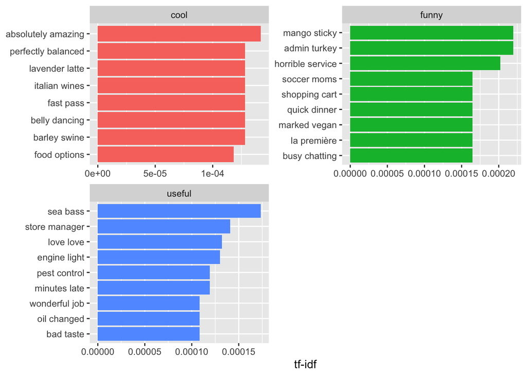

```r
bigram_tf_idf_chart
```

```r
head(trigram_tf_idf, 10)
```

```
##    category                     trigram n           tf      idf       tf_idf
## 1     funny     elderly chinese parents 4 0.0006328113 1.098612 0.0006952142
## 2     funny              3 dozen donuts 2 0.0003164056 1.098612 0.0003476071
## 3     funny                3 piece meal 2 0.0003164056 1.098612 0.0003476071
## 4     funny                     6 30 pm 2 0.0003164056 1.098612 0.0003476071
## 5     funny       bring elderly chinese 2 0.0003164056 1.098612 0.0003476071
## 6     funny       buffalo chicken pizza 2 0.0003164056 1.098612 0.0003476071
## 7     funny        cayenne black pepper 2 0.0003164056 1.098612 0.0003476071
## 8     funny     college football crowds 2 0.0003164056 1.098612 0.0003476071
## 9     funny          cushing square vet 2 0.0003164056 1.098612 0.0003476071
## 10    funny customer service standpoint 2 0.0003164056 1.098612 0.0003476071
```

[figure not shown]

```r
trigram_tf_idf_chart
```

The final result is not great, but it is better than the bag-of-words analysis. using the ngram we can see more meaningful results, but it increases the computation.

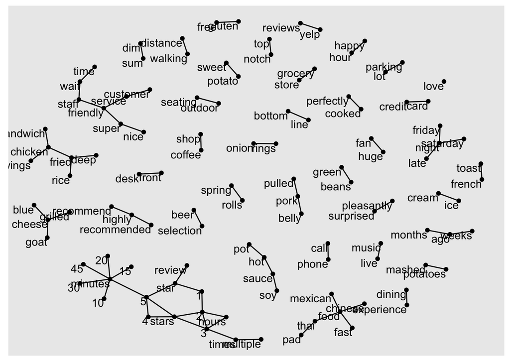

```r
# represent them graphically
bigram_graph <- bigram_counts_separated %>%
  filter(n > 40) %>%
  graph_from_data_frame()

trigram_graph <- trigram_counts_separated %>%
  filter(n > 5) %>%
  graph_from_data_frame()

bigram_graph_nodes <- ggraph(bigram_graph, layout = "fr") +
  geom_edge_link() +
  geom_node_point() +
  geom_node_text(aes(label = name), vjust = 1, hjust = 1)

trigram_graph_nodes <- ggraph(trigram_graph, layout = "fr") +
  geom_edge_link() +
  geom_node_point() +
  geom_node_text(aes(label = name), vjust = 1, hjust = 1)

bigram_graph_nodes
```

[figure not shown]

```r
trigram_graph_nodes
```

The chart above helps us to visualize words with multiple connections. For example ‘customer’ is a key word with many ramifications, and numbers such as ‘1’ can also lead to multiple branches.

[figure not shown]

```r
a <- grid::arrow(type = "closed", length = unit(.08, "inches"))

bigram_graph_direction <- ggraph(bigram_graph, layout = "fr") +
  geom_edge_link(aes(edge_alpha = n), show.legend = FALSE,
                 arrow = a, end_cap = circle(.07, 'inches')) +
  geom_node_point(color = "lightblue", size = 5) +
  geom_node_text(aes(label = name), vjust = 1, hjust = 1) +
  theme_void()

trigram_graph_direction <- ggraph(trigram_graph, layout = "fr") +
  geom_edge_link(aes(edge_alpha = n), show.legend = FALSE,
                 arrow = a, end_cap = circle(.07, 'inches')) +
  geom_node_point(color = "lightblue", size = 5) +
  geom_node_text(aes(label = name), vjust = 1, hjust = 1) +
  theme_void()

bigram_graph_direction
```

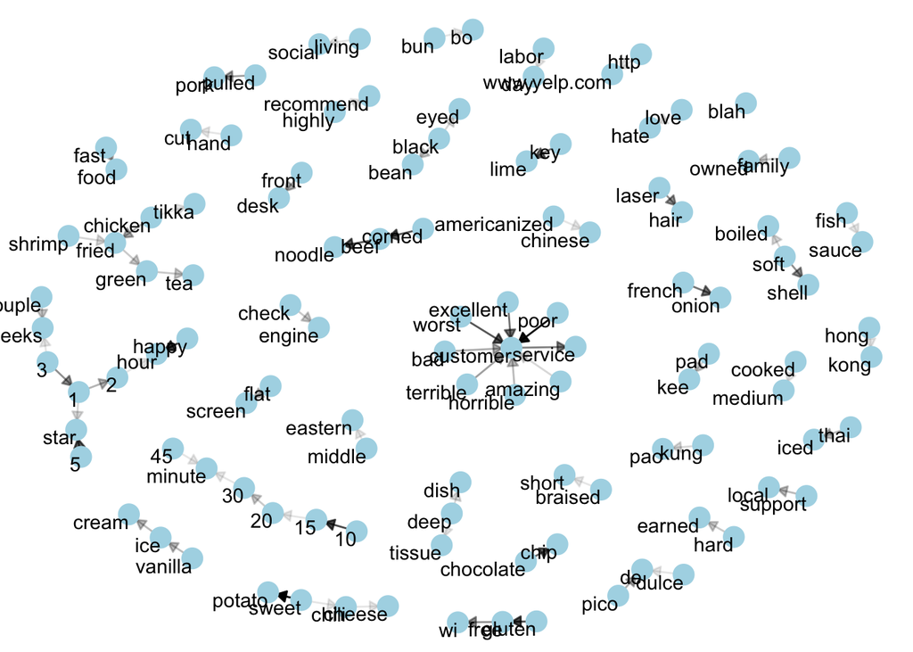

```r
trigram_graph_direction
```

Now can see the direction of the words and understand their relationship

next steps: 1. Verify if we can and if we need to filter companies only in the US 2. Maybe expand the samples to more than 10% 3. Consider smoothing the ngram (in the book) 4. play with numbers on the bigram_graph_direction and trigram_graph_direction to find a better representation

So far, I would say to pick bigram because it is more meaningful than bag-of-words and not too large to compute as the trigram

# Preparing dataset for modeling

```r
# list of selected bigram
summary(bigram_tf_idf)
```

```
##    category        bigram                n                 tf
##  cool  :27775   Length:120484      Min.   :  1.000   Min.   :9.862e-06
##  funny :17465   Class :character   1st Qu.:  1.000   1st Qu.:9.862e-06
##  useful:75244   Mode  :character   Median :  1.000   Median :9.862e-06
##                                    Mean   :  1.293   Mean   :2.490e-05
##                                    3rd Qu.:  1.000   3rd Qu.:2.914e-05
##                                    Max.   :394.000   Max.   :3.886e-03
##       idf             tf_idf
##  Min.   :0.0000   Min.   :0.000e+00
##  1st Qu.:1.0986   1st Qu.:1.083e-05
##  Median :1.0986   Median :1.083e-05
##  Mean   :0.9661   Mean   :1.991e-05
##  3rd Qu.:1.0986   3rd Qu.:3.202e-05
##  Max.   :1.0986   Max.   :2.194e-04
```

```r
quantile(bigram_tf_idf$tf_idf, 0.25)
```

```
##          25%
## 1.083497e-05
```

```r
quantile(bigram_tf_idf$tf_idf, 0.75)
```

```
##          75%
## 3.201551e-05
```

```r
selected_bigram_tf_idf <- bigram_tf_idf %>%
  filter(
    tf_idf >= quantile(bigram_tf_idf$tf_idf, 0.25)
    & tf_idf <= quantile(bigram_tf_idf$tf_idf, 0.75)
    ) %>%
  select(bigram)

mini_dataset <- sample_frac(dataset, 0.001)

# head(mini_dataset, 10)

mini_dataset <- mini_dataset %>%
  mutate(id = row_number())


mini_dataset_ngram <- mini_dataset %>%
  unnest_tokens(bigram, text, token = "ngrams", n = 2) %>%
  separate(bigram, c("word1", "word2"), sep = " ") %>%
  filter(!word1 %in% stop_words$word) %>%
  filter(!word2 %in% stop_words$word) %>%
  unite(bigram, word1, word2, sep = " ") %>%
  filter(bigram %in% bigram_tf_idf$bigram)

mini_dataset_ngram_count <- mini_dataset_ngram %>%
  group_by(id) %>%
  count(bigram, sort = TRUE)


m <- mini_dataset_ngram_count %>%
  cast_sparse(row = id, bigram, n)

dtm_df <- data.frame(as.matrix(m))

dtm_df <- dtm_df %>%
  mutate(id = row.names(dtm_df))

dtm_df$id <- as.integer(dtm_df$id)

dtm_df <- dtm_df %>%
  left_join(mini_dataset)
# Data transformation
# before
# head(mini_dataset_ngram_count, 3)
# after
# head(dtm_df, 3)
```

# Modeling

```r
dtm_df_for_model <- dtm_df %>%
  select(-text) %>%
  sample_frac(.10)

dtm_df_split <- initial_split(dtm_df_for_model,
                                    prop = 0.75,
                                    strata = category)

#training data
dtm_df_training <- dtm_df_split %>%
  training()

#test data
dtm_df_test <- dtm_df_split %>%
  testing()

#Define the model specification with parsnip
lm_dtm_df_def <- multinom_reg() %>%
  # Set the model engine
  set_engine('nnet', MaxNWts = 20000) %>%
  # Set the model mode
  set_mode('classification')

#Train the model with training data
lm_dtm_df <- lm_dtm_df_def %>%
  fit(category ~ .,
      data=dtm_df_training)

#Review model
dtm_Predictions <- predict(lm_dtm_df, new_data = dtm_df_test, type = 'class')
dtm_Probabilities <- predict(lm_dtm_df, new_data = dtm_df_test, type = 'prob')

#combining results
dtmResults <- dtm_df_test %>%
  select(id, category) %>%
  bind_cols(dtm_Predictions, dtm_Probabilities)

head(dtmResults, 10)
```

```
##     id category .pred_class   .pred_cool  .pred_funny .pred_useful
## 1  786    funny      useful 3.661171e-06 6.444538e-11   0.99999634
## 2  445   useful      useful 4.715727e-04 4.007487e-07   0.99952803
## 3   47     cool      useful 3.004431e-04 1.122959e-05   0.99968833
## 4  383   useful        cool 9.271128e-01 7.095790e-04   0.07217764
## 5  554    funny      useful 8.654867e-06 5.110020e-09   0.99999134
## 6  244   useful      useful 1.919550e-03 8.734337e-06   0.99807172
## 7  752     cool      useful 5.515745e-05 3.613495e-09   0.99994484
## 8   83   useful      useful 5.891976e-03 1.027974e-04   0.99400523
## 9  425   useful      useful 5.423038e-04 5.445957e-07   0.99945715
## 10  70     cool      useful 1.313508e-03 1.713833e-05   0.99866935
```

```r
conf_mat <- conf_mat(dtmResults, truth = category, estimate = .pred_class)


conf_mat_mosaic <- conf_mat(dtmResults, truth = category, estimate = .pred_class) %>%
  autoplot(type = 'mosaic')

acc <- accuracy(dtmResults, truth = category, estimate = .pred_class)

conf_mat
```

```
##           Truth
## Prediction cool funny useful
##     cool      0     0      1
##     funny     0     0      0
##     useful    7     2     14
```

[figure not shown]

```r
conf_mat_mosaic
```

```r
acc
```

```
## # A tibble: 1 × 3
##   .metric  .estimator .estimate
##   <chr>    <chr>          <dbl>
## 1 accuracy multiclass     0.583
```

```r
# Save the model
saveRDS(lm_dtm_df, "final_model.rds")
```

- Due to computation cost we are only using a very small fraction of the dataset
- We are considering the most voted category as the classification of a review. Cases where the votes were tied, we selected the first one thatshoed up.